# Testing affect regulation via computational modeling of real-time alcohol choices in daily life — Sensitivity Analyses: Choice Proportion

### 4.3.4 Predicted vs. Observed

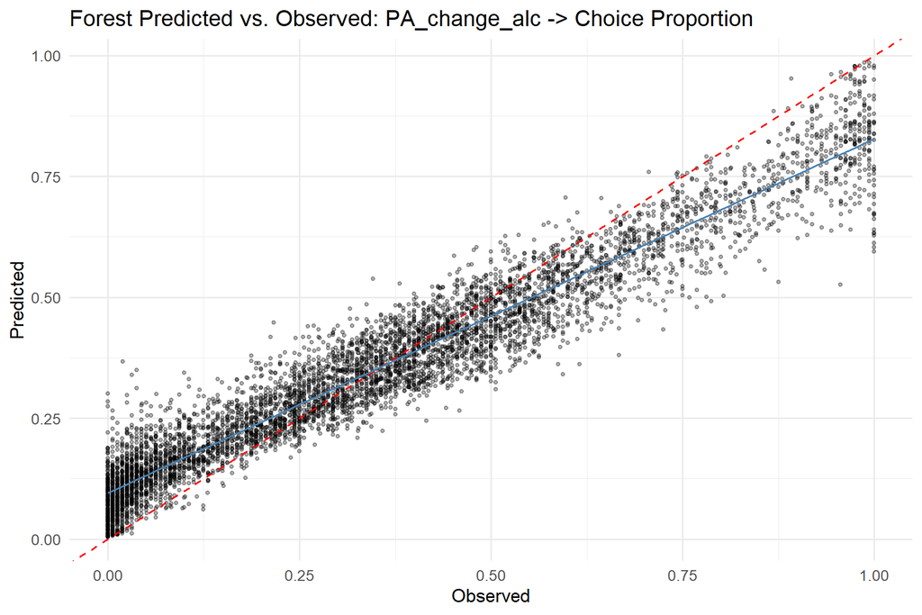

## 4.4 Model Comparison

### 4.4.1 RMSE Comparison (all methods and feature sets)

| Method | Raw | PCA | UMAP |
| --- | --- | --- | --- |
| glmm | 0.2809 | 0.3155 | 0.2867 |
| forest | 0.1907 | 0.2310 | 0.2116 |
| tree | 0.2459 | 0.2613 | 0.2649 |

# 5 Perceived Stress Change (vs. last assessment) (stress_state_change)

## 5.1 Dimensionality Reduction

- **PCA components (80% variance, max 5):** 5
- **UMAP components (matching PCA):** 5

### 5.1.1 PCA Component Composition (top 5 correlated variables)

**PC_1**

| Variable | Correlation |
| --- | --- |
| alc_exp_energeticYes | -0.576 |
| alc_exp_better_moodYes | -0.557 |
| alc_exp_sociableYes | -0.547 |
| alc_exp_buzzYes | -0.502 |
| alc_craving | -0.487 |

**PC_2**

| Variable | Correlation |
| --- | --- |
| alc_exp_injuryYes | -0.596 |
| alc_exp_be_rudeYes | -0.594 |
| alc_exp_embarrassedYes | -0.579 |
| alc_exp_nauseous_vomitYes | -0.491 |
| alc_exp_hangoverYes | -0.468 |

**PC_3**

| Variable | Correlation |
| --- | --- |
| locationschool_work | 0.591 |
| alc_today | -0.579 |
| alc_cuenone | 0.569 |
| time_of_dayevening | -0.476 |
| locationhome | -0.458 |

**PC_4**

| Variable | Correlation |
| --- | --- |
| soft_yday | 0.699 |
| soft_today | 0.651 |
| soft_intend | 0.635 |
| soft_craving | 0.489 |
| alc_exp_embarrassedYes | -0.388 |

**PC_5**

| Variable | Correlation |
| --- | --- |
| locationhome | -0.633 |
| social_context_aloneYes | -0.559 |
| social_context_friend_roommateYes | 0.500 |
| social_context_strangerYes | 0.418 |
| locationsomeone_elses_home | 0.371 |

### 5.1.2 UMAP Component Composition (top 5 correlated variables)

**UMAP_1**

| Variable | Correlation |
| --- | --- |
| alc_exp_embarrassedYes | 0.302 |
| alc_exp_be_rudeYes | 0.298 |
| alc_craving | 0.213 |
| alc_intend | 0.180 |
| alc_yday | 0.160 |

**UMAP_2**

| Variable | Correlation |
| --- | --- |
| alc_yday | -0.359 |
| alc_intend | -0.187 |
| alc_mot_enhanceYes | -0.134 |
| alc_exp_embarrassedYes | 0.115 |
| alc_exp_be_rudeYes | 0.112 |

**UMAP_3**

| Variable | Correlation |
| --- | --- |
| alc_today | -0.369 |
| alc_yday | -0.347 |
| soft_craving | 0.168 |
| alc_cuenone | 0.144 |
| alc_exp_be_rudeYes | 0.140 |

**UMAP_4**

| Variable | Correlation |
| --- | --- |
| soft_yday | 0.773 |
| soft_today | 0.662 |
| soft_intend | 0.551 |
| soft_craving | 0.276 |
| alc_exp_injuryYes | 0.174 |

**UMAP_5**

| Variable | Correlation |
| --- | --- |
| alc_exp_injuryYes | 0.519 |
| alc_exp_embarrassedYes | 0.387 |
| alc_exp_be_rudeYes | 0.384 |
| alc_exp_nauseous_vomitYes | 0.363 |
| alc_exp_energeticYes | 0.228 |

## 5.2 GLMM Results

### 5.2.1 Raw Features

- **Optimal lambda:** 100 (index 1 of 21)
- **CV RMSE:** 0.3039

**Non-zero coefficients** (focal predictor terms highlighted):

| Term | Estimate | Category |
| --- | --- | --- |
| (Intercept) | 0.2276 | Intercept |
| alc_exp_nauseous_vomitYes | -0.0641 | Covariate main effect |
| alc_craving | 0.0562 | Covariate main effect |
| alc_cuenone | -0.0545 | Covariate main effect |
| alc_exp_relaxedYes | 0.0511 | Covariate main effect |
| alc_mot_enhanceYes | 0.0327 | Covariate main effect |
| alc_exp_better_moodYes | 0.0302 | Covariate main effect |
| alc_exp_buzzYes | 0.0237 | Covariate main effect |
| alc_intend | 0.0223 | Covariate main effect |
| time_of_dayevening | 0.0214 | Covariate main effect |
| alc_today | 0.0145 | Covariate main effect |
| alc_mot_copingYes | 0.0112 | Covariate main effect |
| soft_intend | -0.0094 | Covariate main effect |
| soft_craving | -0.0085 | Covariate main effect |
| alc_yday | 0.0045 | Covariate main effect |
| social_context_romantic_partnerYes | 0.0028 | Covariate main effect |
| soft_yday | -0.0026 | Covariate main effect |
| hunger_state | -0.0001 | Covariate main effect |
| alc_exp_energeticYes | 0.0001 | Covariate main effect |
| alc_cuenone:stress_state_change | 0.0012 | Interaction with focal predictor |
| time_of_dayevening:stress_state_change | -0.0006 | Interaction with focal predictor |

- 77 coefficients penalized to zero.*

#### 5.2.1.1 Predicted vs. Observed

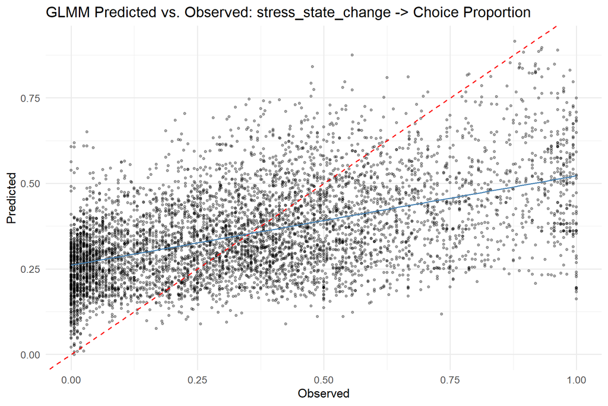

#### 5.2.1.2 Residual Diagnostics

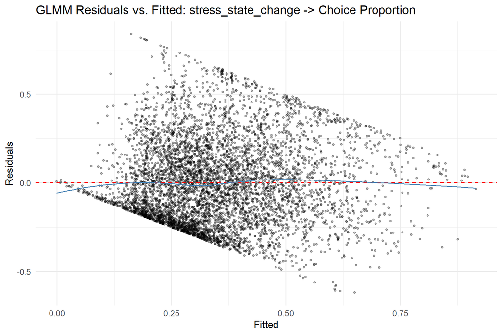

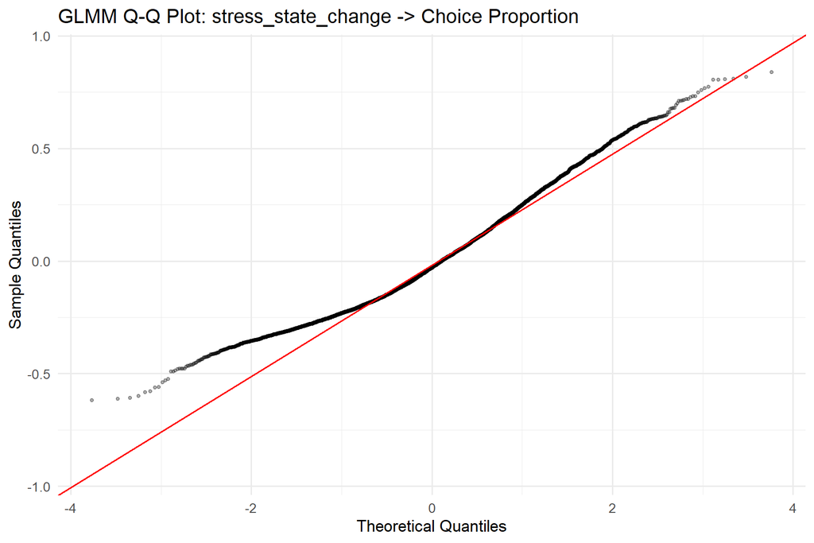

### 5.2.2 PCA Features

- **Optimal lambda:** 65 (index 8 of 21)
- **CV RMSE:** 0.3152

**Non-zero coefficients:**

| Term | Estimate |
| --- | --- |
| (Intercept) | 0.3537 |
| PC_1 | -0.0366 |
| PC_2 | 0.0629 |
| PC_3 | -0.0591 |
| PC_5 | -0.0094 |
| stress_state_change | 0.0025 |
| PC_5:stress_state_change | 0.0040 |

- 5 coefficients penalized to zero.*

### 5.2.3 UMAP Features

- **Optimal lambda:** 100 (index 1 of 21)
- **CV RMSE:** 0.2823

**Non-zero coefficients:**

| Term | Estimate |
| --- | --- |
| (Intercept) | 0.3532 |
| UMAP_3 | -0.0039 |
| UMAP_4 | -0.0192 |
| UMAP_5:stress_state_change | 0.0021 |

- 8 coefficients penalized to zero.*

## 5.3 Random Forest Results (Raw)

### 5.3.1 Tuning Summary

- **mtry:** 12
- **min.node.size:** 2
- **sample.fraction:** 0.804
- **CV RMSE:** 0.1924

### 5.3.2 Variable Importance (Permutation)

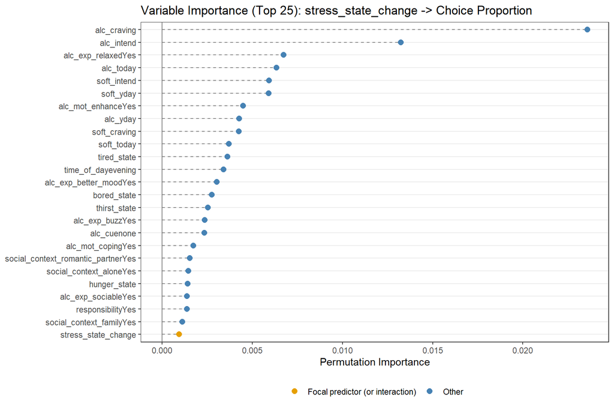

**Full importance ranking:**

| Variable | Importance |
| --- | --- |
| alc_craving | 0.023577 |
| alc_intend | 0.013229 |
| alc_exp_relaxedYes | 0.006738 |
| alc_today | 0.006345 |
| soft_intend | 0.005928 |
| soft_yday | 0.005900 |
| alc_mot_enhanceYes | 0.004485 |
| alc_yday | 0.004271 |
| soft_craving | 0.004245 |
| soft_today | 0.003702 |
| tired_state | 0.003615 |
| time_of_dayevening | 0.003396 |
| alc_exp_better_moodYes | 0.003029 |
| bored_state | 0.002753 |
| thirst_state | 0.002539 |
| alc_exp_buzzYes | 0.002371 |
| alc_cuenone | 0.002346 |
| alc_mot_copingYes | 0.001738 |
| social_context_romantic_partnerYes | 0.001529 |
| social_context_aloneYes | 0.001456 |
| hunger_state | 0.001425 |
| alc_exp_sociableYes | 0.001383 |
| responsibilityYes | 0.001370 |
| social_context_familyYes | 0.001128 |
| stress_state_change | 0.000938 |
| alc_exp_embarrassedYes | 0.000805 |
| alc_exp_hangoverYes | 0.000729 |
| locationhome | 0.000667 |
| alc_exp_energeticYes | 0.000607 |
| locationschool_work | 0.000573 |
| alc_exp_nauseous_vomitYes | 0.000535 |
| alc_exp_be_rudeYes | 0.000495 |
| alc_mot_socialYes | 0.000466 |
| alc_exp_injuryYes | 0.000258 |
| locationother | 0.000172 |
| social_context_friend_roommateYes | 0.000125 |
| alc_cueindirectly_visible | 0.000090 |
| social_context_coworker_classmateYes | 0.000066 |
| locationsomeone_elses_home | 0.000061 |
| social_context_strangerYes | 0.000052 |
| day_of_weekSun | 0.000051 |
| locationoutdoors | 0.000028 |
| social_context_otherYes | 0.000019 |
| day_of_weekSat | 0.000016 |
| locationrestaurant_cafe | 0.000013 |
| day_of_weekWed | -0.000080 |
| day_of_weekMon | -0.000086 |
| day_of_weekTue | -0.000107 |
| day_of_weekThu | -0.000110 |

### 5.3.3 Partial Dependence Plots

PDP for the focal predictor and the top 5 most important non-interaction covariates.

#### 5.3.3.1 Focal Predictor: stress_state_change

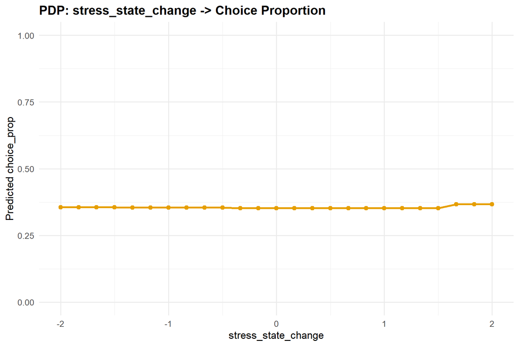

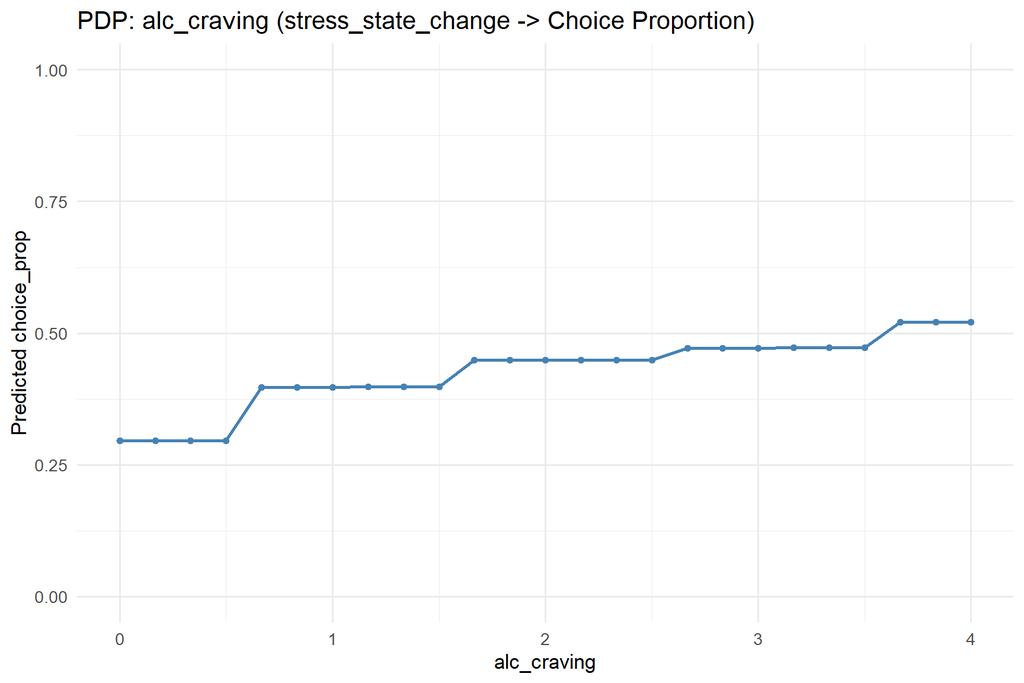

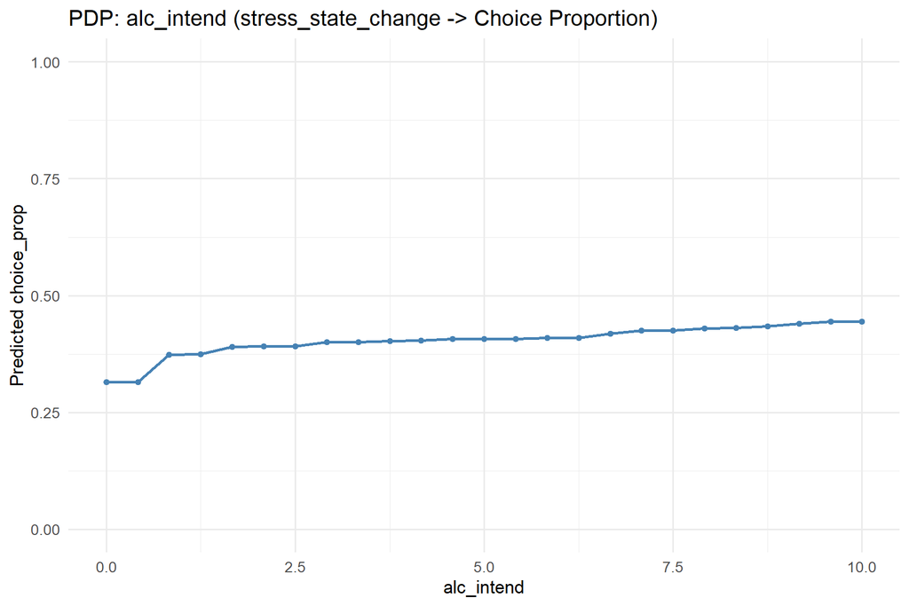

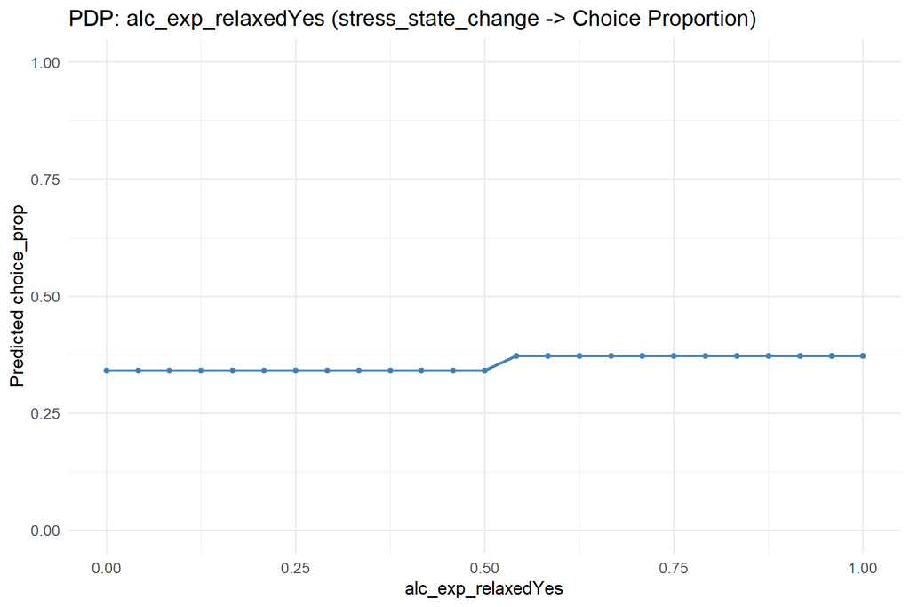

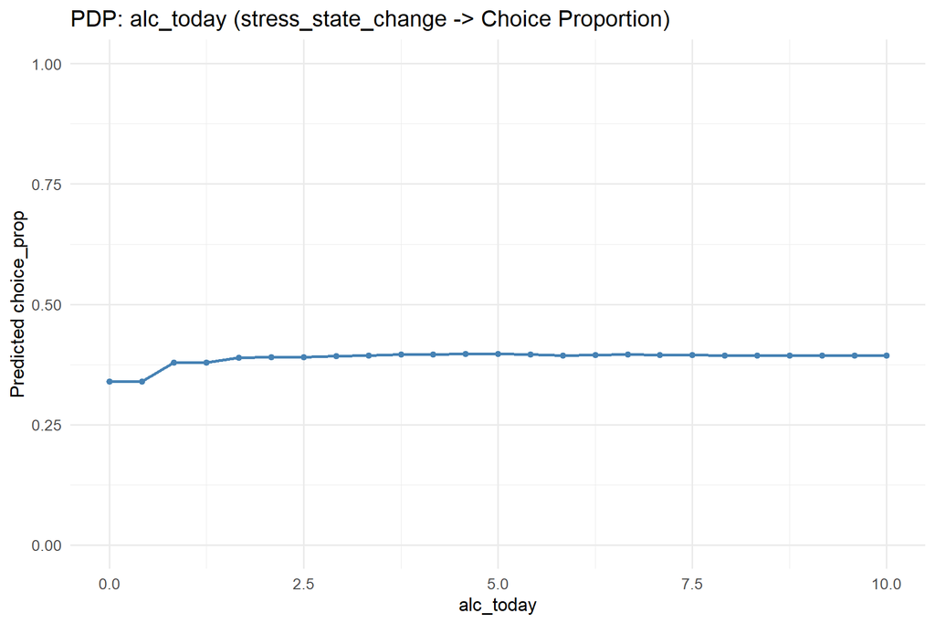

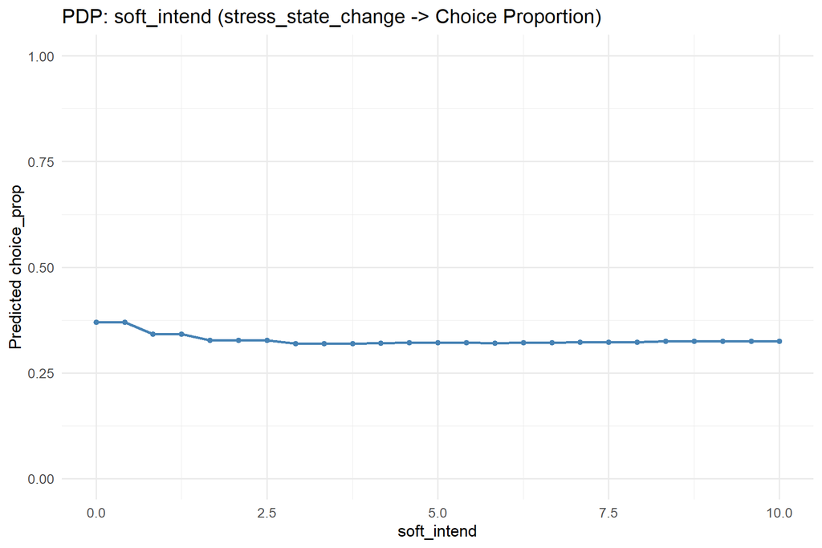

### 5.3.4 Predicted vs. Observed

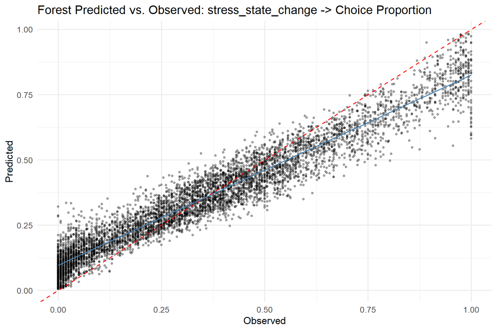

## 5.4 Model Comparison

### 5.4.1 RMSE Comparison (all methods and feature sets)

| Method | Raw | PCA | UMAP |
| --- | --- | --- | --- |
| glmm | 0.3039 | 0.3152 | 0.2823 |
| forest | 0.1924 | 0.2338 | 0.2152 |
| tree | 0.2461 | 0.2623 | 0.2584 |

# 6 Perceived Negative Affect Change (vs. last assessment) (NA_state_change)

## 6.1 Dimensionality Reduction

- **PCA components (80% variance, max 5):** 5
- **UMAP components (matching PCA):** 5

### 6.1.1 PCA Component Composition (top 5 correlated variables)

**PC_1**

| Variable | Correlation |
| --- | --- |
| alc_exp_energeticYes | -0.576 |
| alc_exp_better_moodYes | -0.557 |
| alc_exp_sociableYes | -0.547 |
| alc_exp_buzzYes | -0.503 |
| alc_craving | -0.487 |

**PC_2**

| Variable | Correlation |
| --- | --- |
| alc_exp_injuryYes | -0.596 |
| alc_exp_be_rudeYes | -0.594 |
| alc_exp_embarrassedYes | -0.579 |
| alc_exp_nauseous_vomitYes | -0.491 |
| alc_exp_hangoverYes | -0.468 |

**PC_3**

| Variable | Correlation |
| --- | --- |
| locationschool_work | 0.591 |
| alc_today | -0.578 |
| alc_cuenone | 0.569 |
| time_of_dayevening | -0.476 |
| locationhome | -0.458 |

**PC_4**

| Variable | Correlation |
| --- | --- |
| soft_yday | 0.699 |
| soft_today | 0.650 |
| soft_intend | 0.634 |
| soft_craving | 0.488 |
| alc_exp_embarrassedYes | -0.388 |

**PC_5**

| Variable | Correlation |
| --- | --- |
| locationhome | -0.632 |
| social_context_aloneYes | -0.560 |
| social_context_friend_roommateYes | 0.500 |
| social_context_strangerYes | 0.417 |
| locationsomeone_elses_home | 0.371 |

### 6.1.2 UMAP Component Composition (top 5 correlated variables)

**UMAP_1**

| Variable | Correlation |
| --- | --- |
| alc_exp_embarrassedYes | -0.304 |
| alc_exp_be_rudeYes | -0.300 |
| alc_craving | -0.258 |
| alc_intend | -0.221 |
| alc_yday | -0.163 |

**UMAP_2**

| Variable | Correlation |
| --- | --- |
| alc_yday | 0.353 |
| alc_exp_embarrassedYes | -0.166 |
| alc_exp_be_rudeYes | -0.162 |
| alc_intend | 0.152 |
| alc_mot_enhanceYes | 0.119 |

**UMAP_3**

| Variable | Correlation |
| --- | --- |
| alc_today | 0.381 |
| alc_yday | 0.373 |
| alc_cuenone | -0.157 |
| soft_craving | -0.149 |
| alc_exp_be_rudeYes | -0.144 |

**UMAP_4**

| Variable | Correlation |
| --- | --- |
| soft_yday | -0.767 |
| soft_today | -0.660 |
| soft_intend | -0.540 |
| soft_craving | -0.278 |
| alc_exp_be_rudeYes | -0.150 |

**UMAP_5**

| Variable | Correlation |
| --- | --- |
| alc_exp_injuryYes | 0.522 |
| alc_exp_embarrassedYes | 0.389 |
| alc_exp_be_rudeYes | 0.387 |
| alc_exp_nauseous_vomitYes | 0.369 |
| alc_exp_energeticYes | 0.224 |

## 6.2 GLMM Results

### 6.2.1 Raw Features

- **Optimal lambda:** 100 (index 1 of 21)
- **CV RMSE:** 0.3039

**Non-zero coefficients** (focal predictor terms highlighted):

| Term | Estimate | Category |
| --- | --- | --- |
| (Intercept) | 0.2091 | Intercept |
| alc_exp_nauseous_vomitYes | -0.0676 | Covariate main effect |
| alc_cuenone | -0.0592 | Covariate main effect |
| alc_craving | 0.0567 | Covariate main effect |
| alc_exp_relaxedYes | 0.0558 | Covariate main effect |
| alc_mot_enhanceYes | 0.0383 | Covariate main effect |
| alc_exp_better_moodYes | 0.0372 | Covariate main effect |
| alc_exp_buzzYes | 0.0294 | Covariate main effect |
| alc_intend | 0.0236 | Covariate main effect |
| time_of_dayevening | 0.0209 | Covariate main effect |
| alc_mot_copingYes | 0.0180 | Covariate main effect |
| alc_today | 0.0157 | Covariate main effect |
| alc_exp_energeticYes | 0.0096 | Covariate main effect |
| soft_intend | -0.0089 | Covariate main effect |
| soft_craving | -0.0083 | Covariate main effect |
| alc_exp_sociableYes | 0.0061 | Covariate main effect |
| alc_yday | 0.0056 | Covariate main effect |
| social_context_romantic_partnerYes | 0.0034 | Covariate main effect |
| soft_yday | -0.0028 | Covariate main effect |
| thirst_state | 0.0012 | Covariate main effect |
| alc_cuenone:NA_state_change | 0.0041 | Interaction with focal predictor |
| time_of_dayevening:NA_state_change | 0.0040 | Interaction with focal predictor |

- 76 coefficients penalized to zero.*

#### 6.2.1.1 Predicted vs. Observed

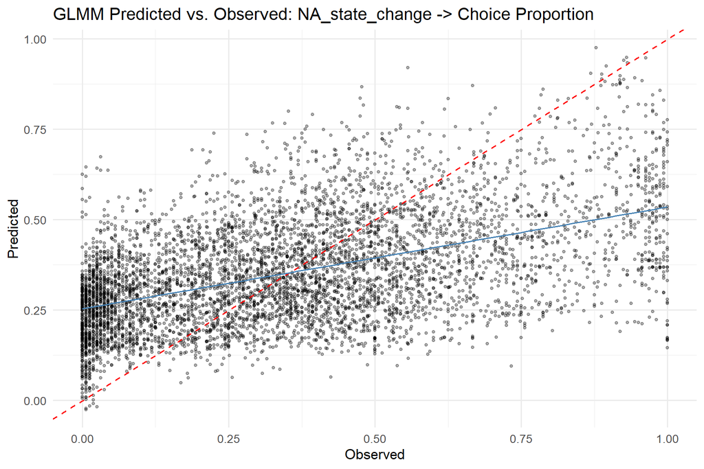

#### 6.2.1.2 Residual Diagnostics

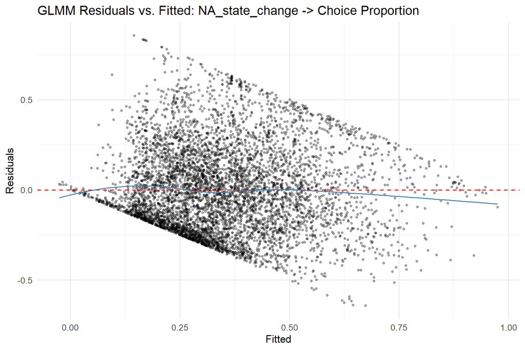

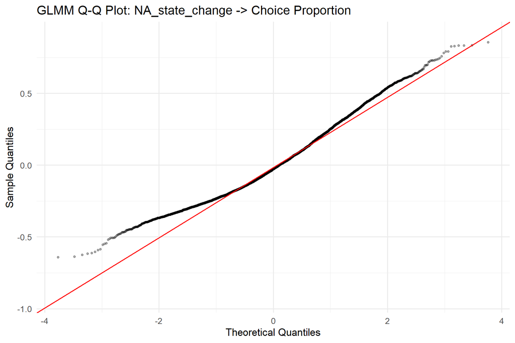

### 6.2.2 PCA Features

- **Optimal lambda:** 65 (index 8 of 21)
- **CV RMSE:** 0.3144

**Non-zero coefficients:**

| Term | Estimate |
| --- | --- |
| (Intercept) | 0.3532 |
| PC_1 | -0.0361 |
| PC_2 | 0.0626 |
| PC_3 | -0.0588 |
| PC_5 | -0.0104 |
| NA_state_change | 0.0041 |
| PC_5:NA_state_change | -0.0034 |

- 5 coefficients penalized to zero.*

### 6.2.3 UMAP Features

- **Optimal lambda:** 100 (index 1 of 21)
- **CV RMSE:** 0.2779

**Non-zero coefficients:**

| Term | Estimate |
| --- | --- |
| (Intercept) | 0.3530 |
| UMAP_1 | -0.0015 |
| UMAP_3 | 0.0120 |
| UMAP_4 | 0.0267 |
| UMAP_5:NA_state_change | 0.0014 |

- 7 coefficients penalized to zero.*

## 6.3 Random Forest Results (Raw)

### 6.3.1 Tuning Summary

- **mtry:** 13
- **min.node.size:** 2
- **sample.fraction:** 0.882
- **CV RMSE:** 0.1927

### 6.3.2 Variable Importance (Permutation)

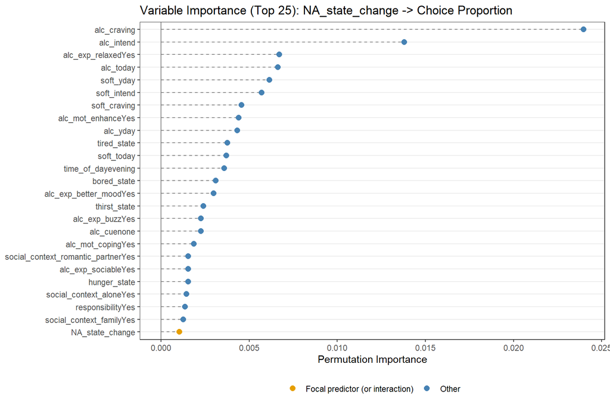

**Full importance ranking:**

| Variable | Importance |
| --- | --- |
| alc_craving | 0.023970 |
| alc_intend | 0.013804 |
| alc_exp_relaxedYes | 0.006702 |
| alc_today | 0.006620 |
| soft_yday | 0.006154 |
| soft_intend | 0.005703 |
| soft_craving | 0.004569 |
| alc_mot_enhanceYes | 0.004403 |
| alc_yday | 0.004317 |
| tired_state | 0.003764 |
| soft_today | 0.003693 |
| time_of_dayevening | 0.003586 |
| bored_state | 0.003097 |
| alc_exp_better_moodYes | 0.002974 |
| thirst_state | 0.002408 |
| alc_exp_buzzYes | 0.002261 |
| alc_cuenone | 0.002261 |
| alc_mot_copingYes | 0.001855 |
| social_context_romantic_partnerYes | 0.001545 |
| alc_exp_sociableYes | 0.001532 |
| hunger_state | 0.001531 |
| social_context_aloneYes | 0.001447 |
| responsibilityYes | 0.001351 |
| social_context_familyYes | 0.001262 |
| NA_state_change | 0.001030 |
| alc_exp_embarrassedYes | 0.000848 |
| alc_exp_hangoverYes | 0.000845 |
| locationhome | 0.000731 |
| locationschool_work | 0.000623 |
| alc_exp_nauseous_vomitYes | 0.000614 |
| alc_exp_energeticYes | 0.000599 |
| alc_mot_socialYes | 0.000534 |
| alc_exp_be_rudeYes | 0.000440 |
| alc_exp_injuryYes | 0.000279 |
| locationother | 0.000157 |
| alc_cueindirectly_visible | 0.000097 |
| social_context_friend_roommateYes | 0.000090 |
| locationsomeone_elses_home | 0.000066 |
| social_context_strangerYes | 0.000060 |
| day_of_weekSat | 0.000054 |
| locationoutdoors | 0.000051 |
| social_context_coworker_classmateYes | 0.000044 |
| day_of_weekSun | 0.000026 |
| locationrestaurant_cafe | 0.000018 |
| social_context_otherYes | 0.000012 |
| day_of_weekWed | -0.000074 |
| day_of_weekMon | -0.000113 |
| day_of_weekThu | -0.000124 |
| day_of_weekTue | -0.000139 |

### 6.3.3 Partial Dependence Plots

PDP for the focal predictor and the top 5 most important non-interaction covariates.

#### 6.3.3.1 Focal Predictor: NA_state_change

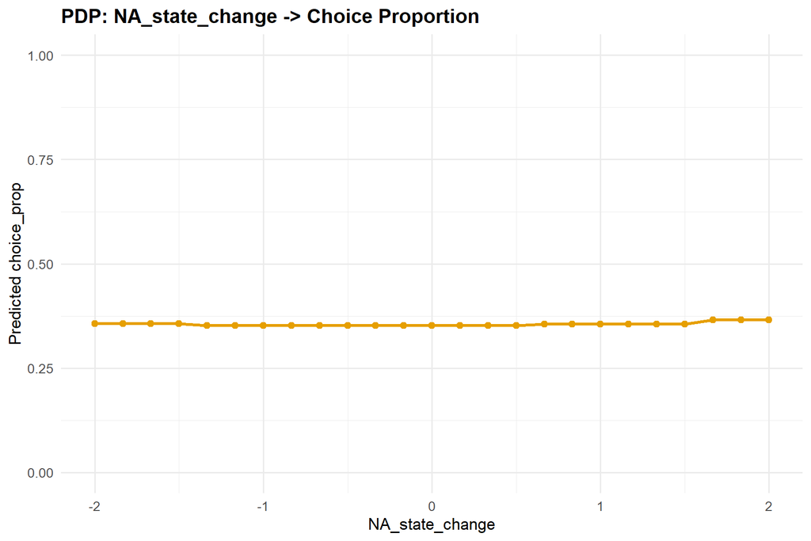

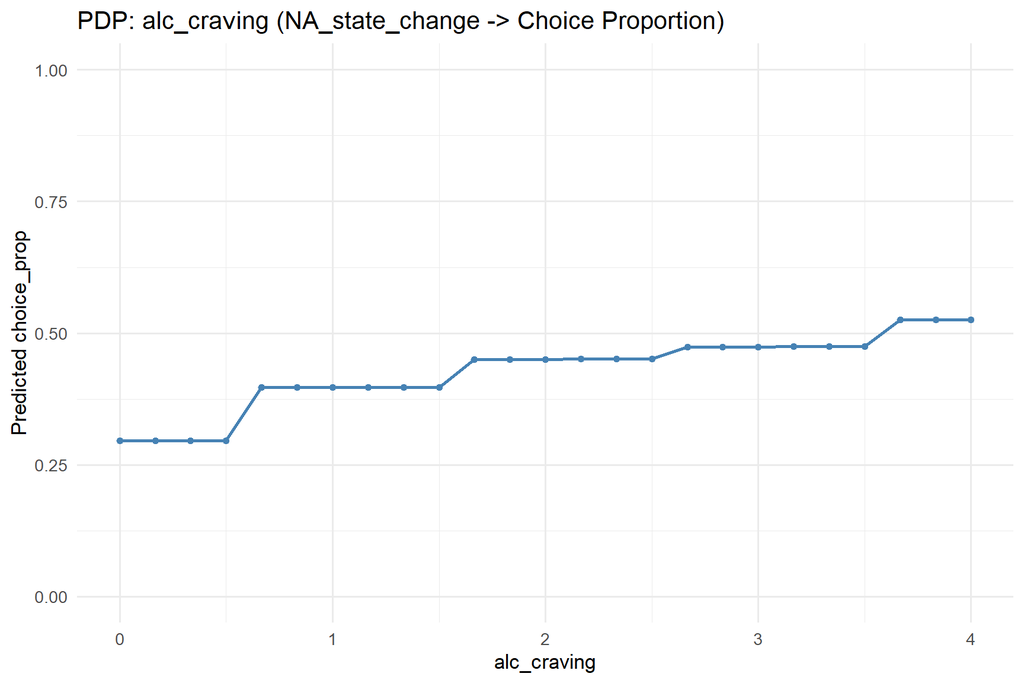

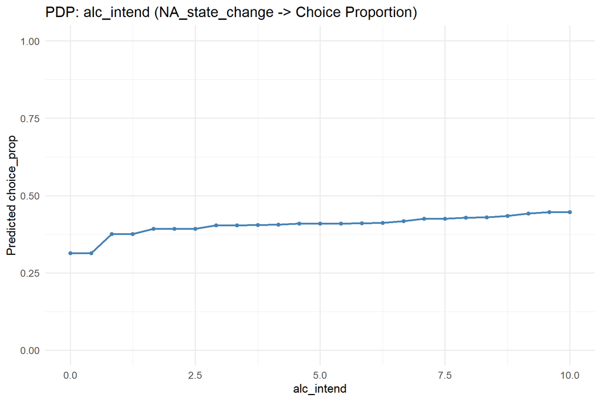

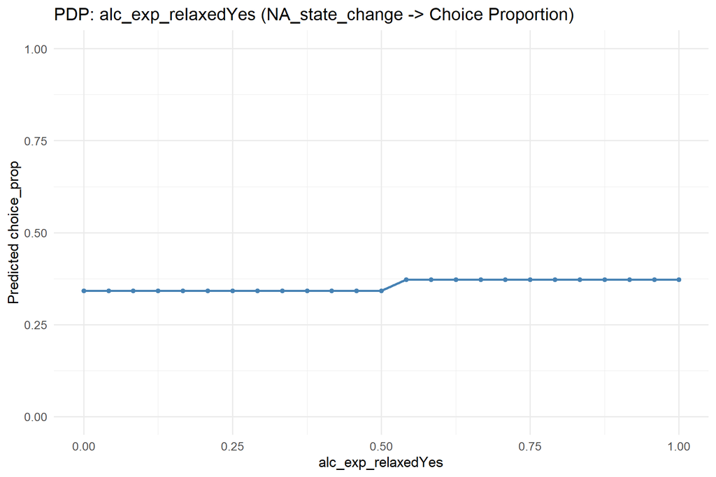

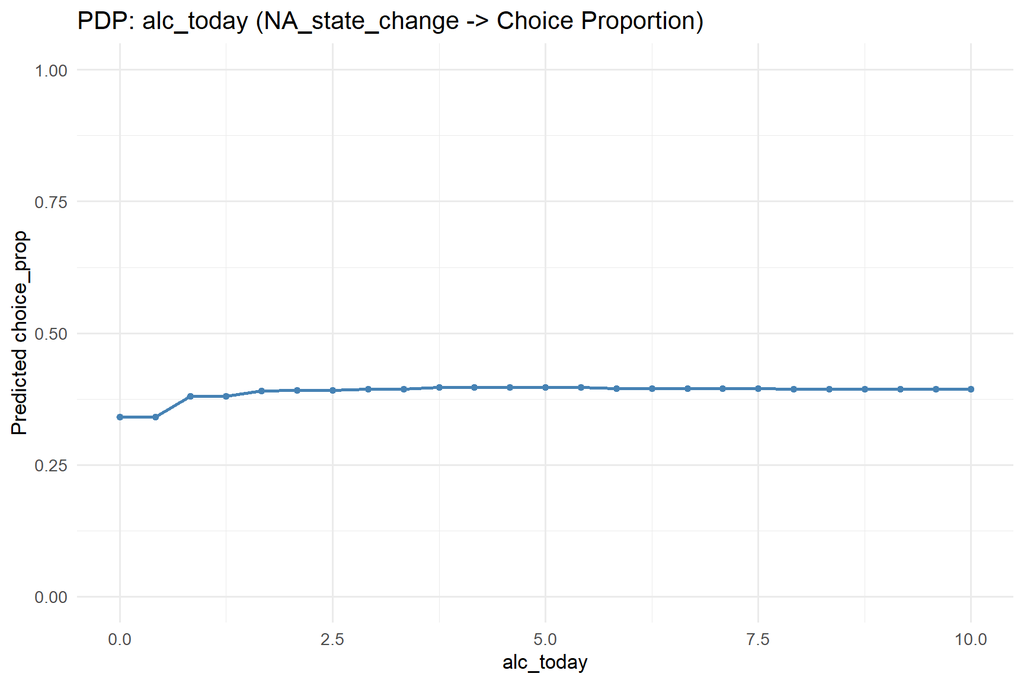

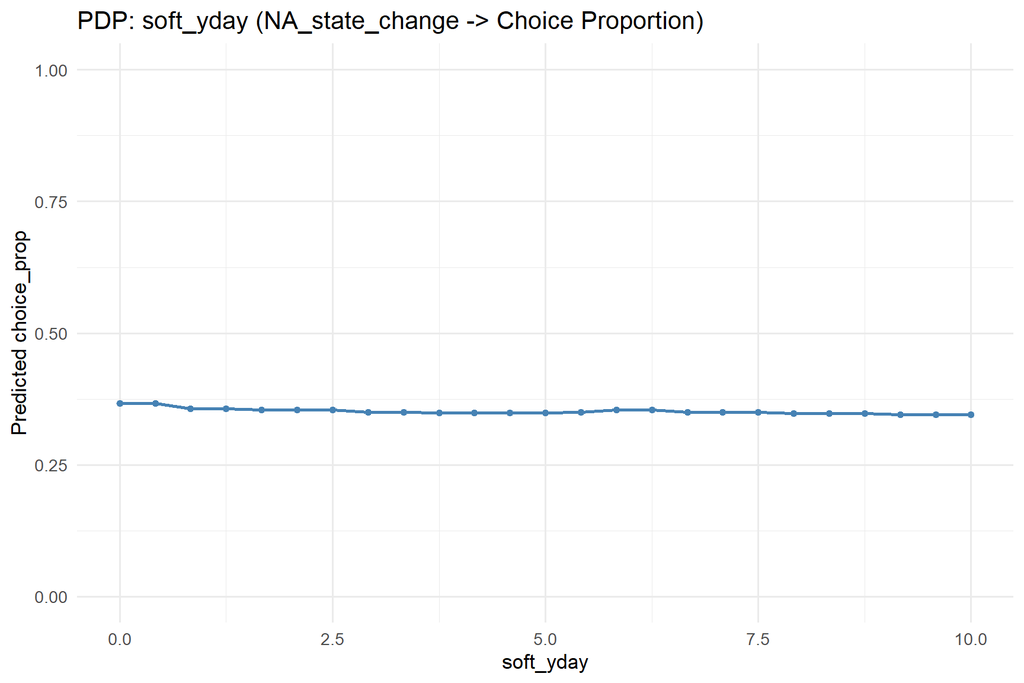

### 6.3.4 Predicted vs. Observed

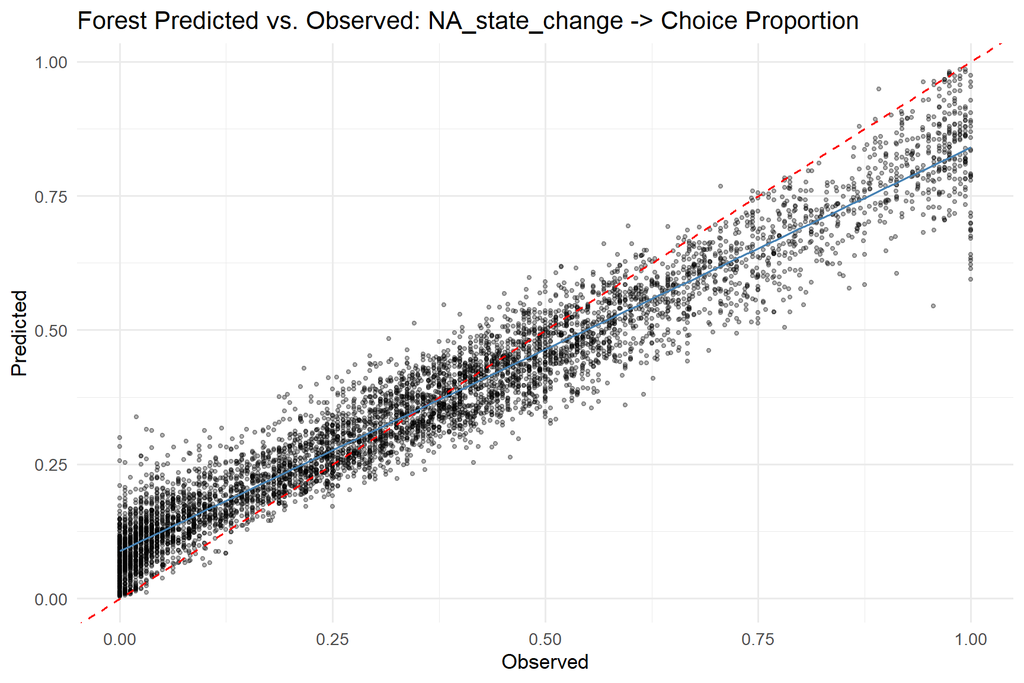

## 6.4 Model Comparison

### 6.4.1 RMSE Comparison (all methods and feature sets)

| Method | Raw | PCA | UMAP |
| --- | --- | --- | --- |
| glmm | 0.3039 | 0.3144 | 0.2779 |
| forest | 0.1927 | 0.2342 | 0.2149 |
| tree | 0.2461 | 0.2616 | 0.2639 |

# 7 Perceived Positive Affect Change (vs. last assessment) (PA_state_change)

## 7.1 Dimensionality Reduction

- **PCA components (80% variance, max 5):** 5
- **UMAP components (matching PCA):** 5

### 7.1.1 PCA Component Composition (top 5 correlated variables)

**PC_1**

| Variable | Correlation |
| --- | --- |
| alc_exp_energeticYes | -0.576 |
| alc_exp_better_moodYes | -0.557 |
| alc_exp_sociableYes | -0.547 |
| alc_exp_buzzYes | -0.502 |
| alc_craving | -0.487 |

**PC_2**

| Variable | Correlation |
| --- | --- |
| alc_exp_injuryYes | -0.595 |
| alc_exp_be_rudeYes | -0.593 |
| alc_exp_embarrassedYes | -0.578 |
| alc_exp_nauseous_vomitYes | -0.491 |
| alc_exp_hangoverYes | -0.468 |

**PC_3**

| Variable | Correlation |
| --- | --- |
| locationschool_work | 0.590 |
| alc_today | -0.578 |
| alc_cuenone | 0.568 |
| time_of_dayevening | -0.476 |
| locationhome | -0.457 |

**PC_4**

| Variable | Correlation |
| --- | --- |
| soft_yday | 0.699 |
| soft_today | 0.650 |
| soft_intend | 0.633 |
| soft_craving | 0.488 |
| alc_exp_embarrassedYes | -0.389 |

**PC_5**

| Variable | Correlation |
| --- | --- |
| locationhome | -0.633 |
| social_context_aloneYes | -0.560 |
| social_context_friend_roommateYes | 0.500 |
| social_context_strangerYes | 0.417 |
| locationsomeone_elses_home | 0.371 |

### 7.1.2 UMAP Component Composition (top 5 correlated variables)

**UMAP_1**

| Variable | Correlation |
| --- | --- |
| alc_exp_embarrassedYes | 0.291 |
| alc_exp_be_rudeYes | 0.287 |
| alc_craving | 0.221 |
| alc_intend | 0.185 |
| alc_yday | 0.166 |

**UMAP_2**

| Variable | Correlation |
| --- | --- |
| alc_yday | -0.263 |
| alc_exp_embarrassedYes | 0.153 |
| alc_exp_be_rudeYes | 0.149 |
| alc_mot_enhanceYes | -0.116 |
| alc_intend | -0.111 |

**UMAP_3**

| Variable | Correlation |
| --- | --- |
| alc_yday | -0.439 |
| alc_today | -0.399 |
| alc_cuenone | 0.172 |
| alc_intend | -0.153 |
| social_context_familyYes | -0.133 |

**UMAP_4**

| Variable | Correlation |
| --- | --- |
| soft_yday | 0.810 |
| soft_today | 0.693 |
| soft_intend | 0.589 |
| soft_craving | 0.319 |
| alc_exp_injuryYes | 0.172 |

**UMAP_5**

| Variable | Correlation |
| --- | --- |
| alc_exp_injuryYes | 0.513 |
| alc_exp_embarrassedYes | 0.383 |
| alc_exp_be_rudeYes | 0.380 |
| alc_exp_nauseous_vomitYes | 0.358 |
| alc_exp_energeticYes | 0.232 |

## 7.2 GLMM Results

### 7.2.1 Raw Features

- **Optimal lambda:** 100 (index 1 of 21)
- **CV RMSE:** 0.3038

**Non-zero coefficients** (focal predictor terms highlighted):

| Term | Estimate | Category |
| --- | --- | --- |
| (Intercept) | 0.2089 | Intercept |
| alc_exp_nauseous_vomitYes | -0.0678 | Covariate main effect |
| alc_cuenone | -0.0593 | Covariate main effect |
| alc_craving | 0.0568 | Covariate main effect |
| alc_exp_relaxedYes | 0.0559 | Covariate main effect |
| alc_mot_enhanceYes | 0.0385 | Covariate main effect |
| alc_exp_better_moodYes | 0.0374 | Covariate main effect |
| alc_exp_buzzYes | 0.0296 | Covariate main effect |
| alc_intend | 0.0237 | Covariate main effect |
| time_of_dayevening | 0.0207 | Covariate main effect |
| alc_mot_copingYes | 0.0182 | Covariate main effect |
| alc_today | 0.0157 | Covariate main effect |
| alc_exp_energeticYes | 0.0099 | Covariate main effect |
| soft_intend | -0.0088 | Covariate main effect |
| soft_craving | -0.0083 | Covariate main effect |
| alc_exp_sociableYes | 0.0063 | Covariate main effect |
| alc_yday | 0.0056 | Covariate main effect |
| social_context_romantic_partnerYes | 0.0036 | Covariate main effect |
| soft_yday | -0.0027 | Covariate main effect |
| thirst_state | 0.0012 | Covariate main effect |
| alc_cuenone:PA_state_change | -0.0083 | Interaction with focal predictor |
| time_of_dayevening:PA_state_change | -0.0009 | Interaction with focal predictor |

- 76 coefficients penalized to zero.*

#### 7.2.1.1 Predicted vs. Observed

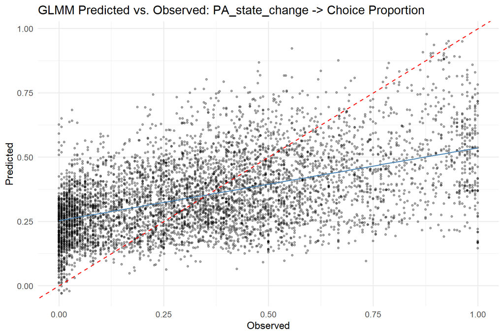

#### 7.2.1.2 Residual Diagnostics

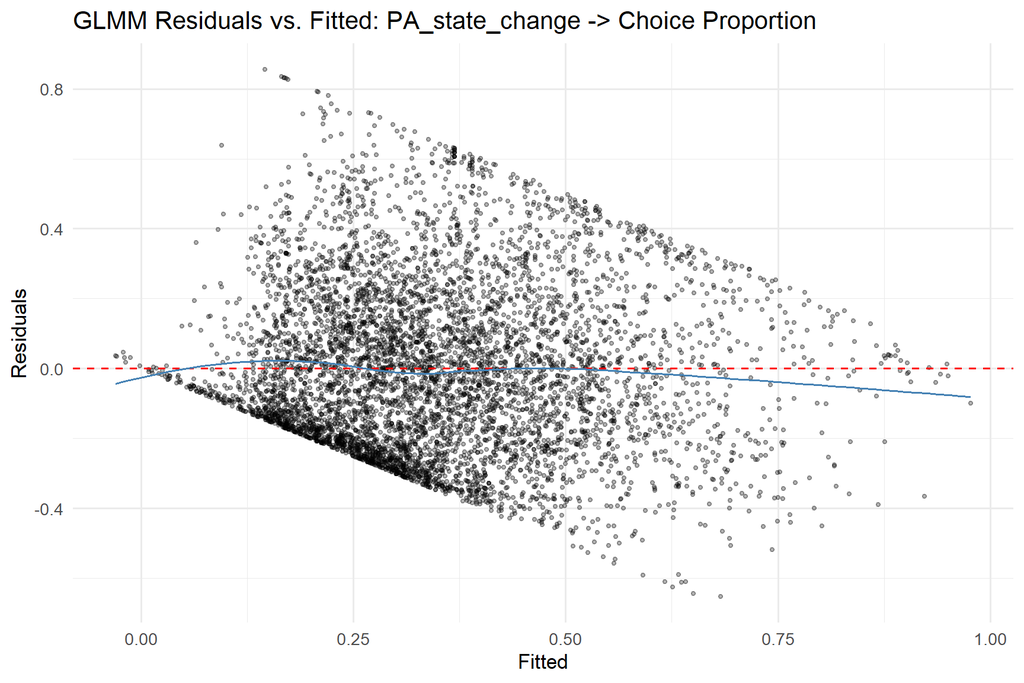

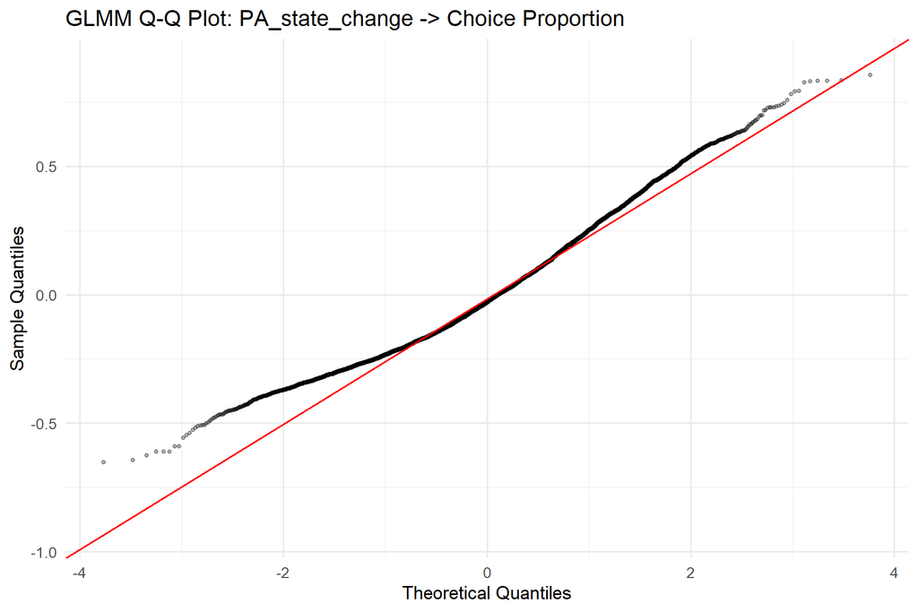

### 7.2.2 PCA Features

- **Optimal lambda:** 65 (index 8 of 21)
- **CV RMSE:** 0.3106

**Non-zero coefficients:**

| Term | Estimate |
| --- | --- |
| (Intercept) | 0.3544 |
| PC_1 | -0.0374 |
| PC_2 | 0.0645 |
| PC_3 | -0.0601 |
| PC_5 | -0.0104 |
| PA_state_change | -0.0067 |
| PC_3:PA_state_change | 0.0001 |
| PC_5:PA_state_change | -0.0002 |

- 4 coefficients penalized to zero.*

### 7.2.3 UMAP Features

- **Optimal lambda:** 85 (index 4 of 21)
- **CV RMSE:** 0.2831

**Non-zero coefficients:**

| Term | Estimate |
| --- | --- |
| (Intercept) | 0.3533 |
| UMAP_1 | 0.0035 |
| UMAP_2 | -0.0059 |
| UMAP_3 | -0.0163 |
| UMAP_4 | -0.0260 |
| UMAP_1:PA_state_change | 0.0015 |
| UMAP_5:PA_state_change | -0.0078 |

- 5 coefficients penalized to zero.*

## 7.3 Random Forest Results (Raw)

### 7.3.1 Tuning Summary

- **mtry:** 13
- **min.node.size:** 2
- **sample.fraction:** 0.898
- **CV RMSE:** 0.1927

### 7.3.2 Variable Importance (Permutation)

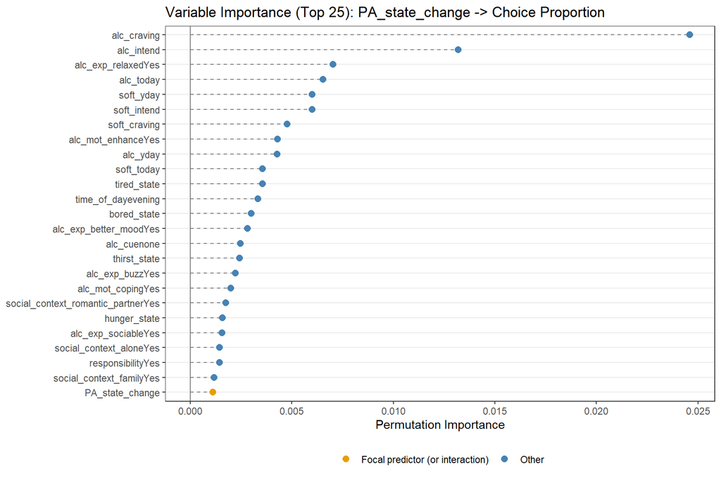

**Full importance ranking:**

| Variable | Importance |
| --- | --- |
| alc_craving | 0.024600 |
| alc_intend | 0.013201 |
| alc_exp_relaxedYes | 0.007031 |
| alc_today | 0.006535 |
| soft_yday | 0.006007 |
| soft_intend | 0.006006 |
| soft_craving | 0.004766 |
| alc_mot_enhanceYes | 0.004291 |
| alc_yday | 0.004277 |
| soft_today | 0.003556 |
| tired_state | 0.003555 |
| time_of_dayevening | 0.003332 |
| bored_state | 0.002989 |
| alc_exp_better_moodYes | 0.002814 |
| alc_cuenone | 0.002471 |
| thirst_state | 0.002430 |
| alc_exp_buzzYes | 0.002209 |
| alc_mot_copingYes | 0.001985 |
| social_context_romantic_partnerYes | 0.001743 |
| hunger_state | 0.001572 |
| alc_exp_sociableYes | 0.001561 |
| social_context_aloneYes | 0.001445 |
| responsibilityYes | 0.001429 |
| social_context_familyYes | 0.001177 |
| PA_state_change | 0.001107 |
| alc_exp_embarrassedYes | 0.000873 |
| alc_exp_hangoverYes | 0.000794 |
| locationhome | 0.000720 |
| alc_exp_nauseous_vomitYes | 0.000627 |
| alc_exp_energeticYes | 0.000549 |
| locationschool_work | 0.000544 |
| alc_exp_be_rudeYes | 0.000494 |
| alc_mot_socialYes | 0.000429 |
| alc_exp_injuryYes | 0.000282 |
| locationother | 0.000166 |
| social_context_friend_roommateYes | 0.000129 |
| social_context_coworker_classmateYes | 0.000077 |
| alc_cueindirectly_visible | 0.000076 |
| locationsomeone_elses_home | 0.000073 |
| social_context_strangerYes | 0.000067 |
| day_of_weekSun | 0.000051 |
| locationoutdoors | 0.000044 |
| day_of_weekSat | 0.000018 |
| locationrestaurant_cafe | 0.000017 |
| social_context_otherYes | 0.000013 |
| day_of_weekTue | -0.000054 |
| day_of_weekMon | -0.000075 |
| day_of_weekWed | -0.000086 |
| day_of_weekThu | -0.000092 |

### 7.3.3 Partial Dependence Plots

PDP for the focal predictor and the top 5 most important non-interaction covariates.

#### 7.3.3.1 Focal Predictor: PA_state_change

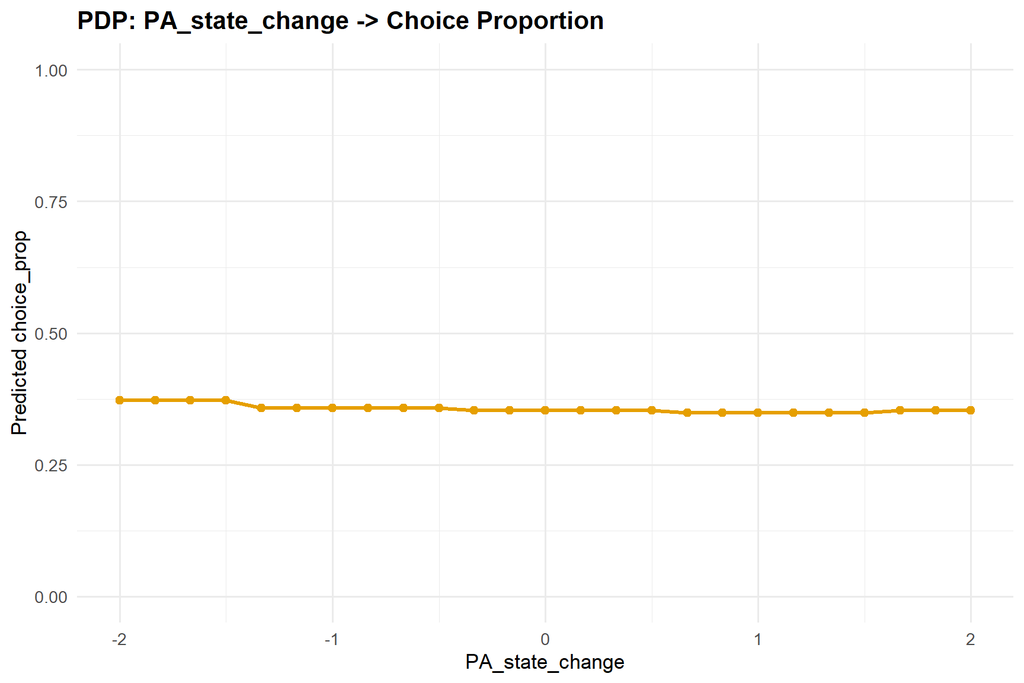

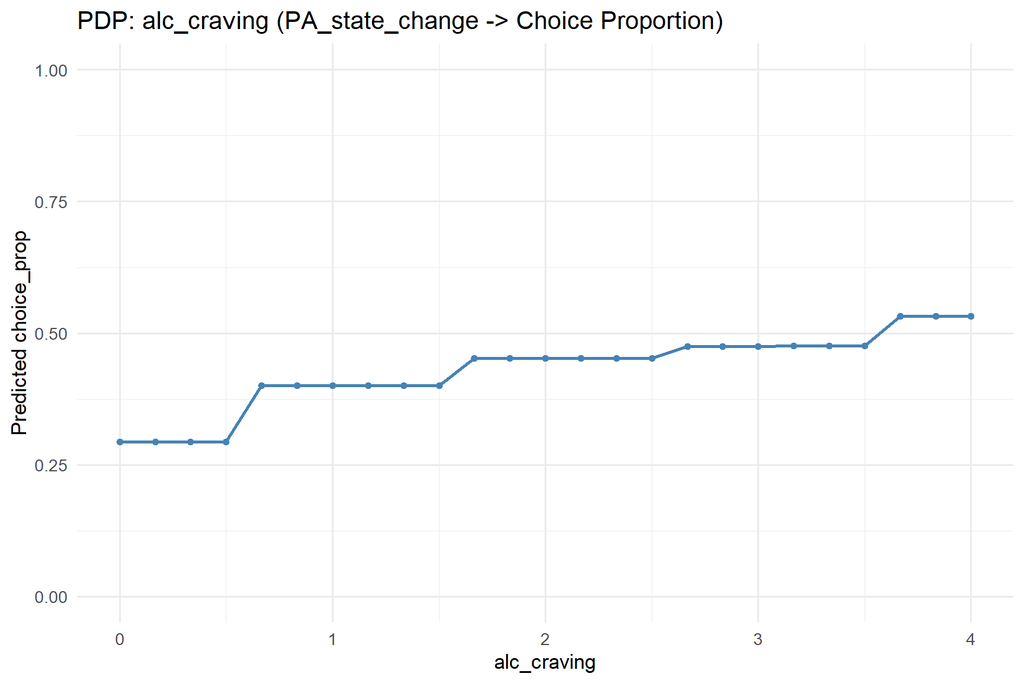

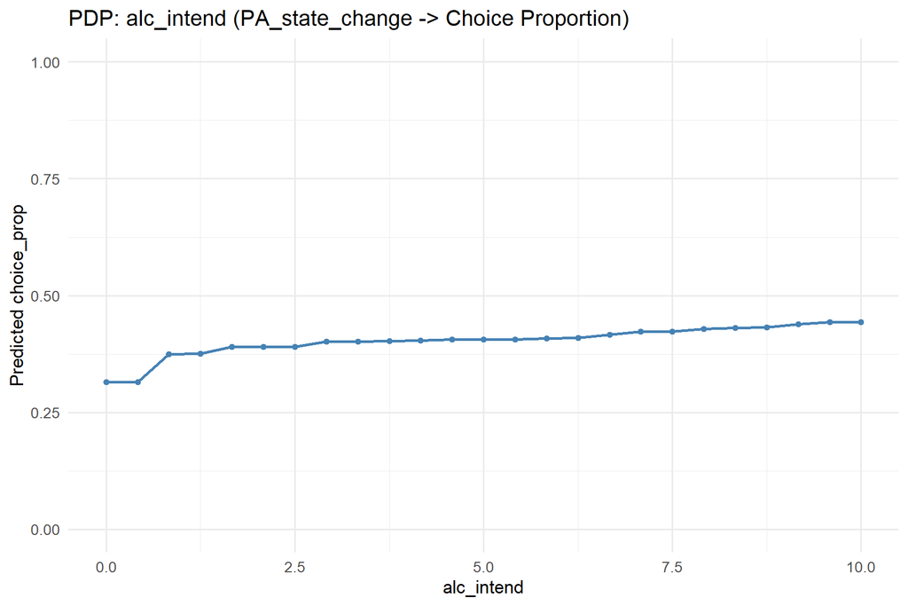

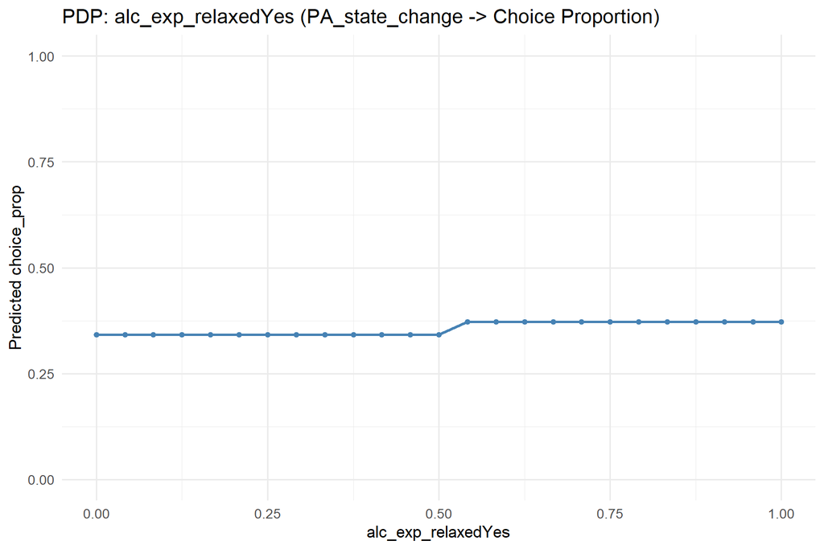

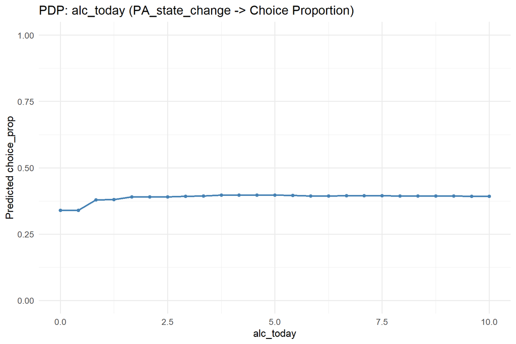

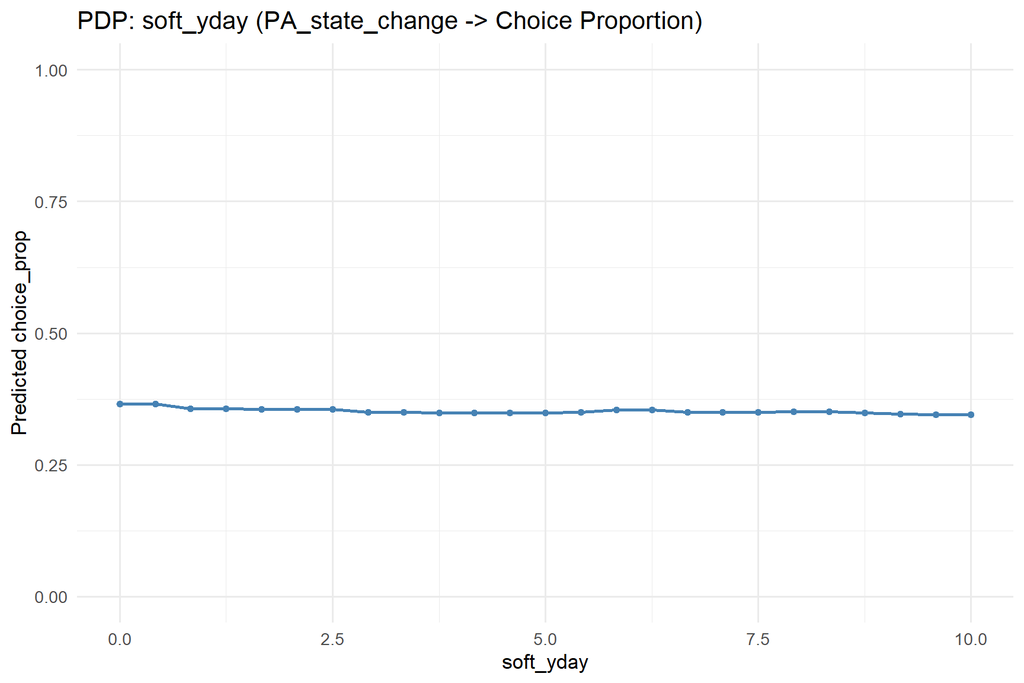

### 7.3.4 Predicted vs. Observed

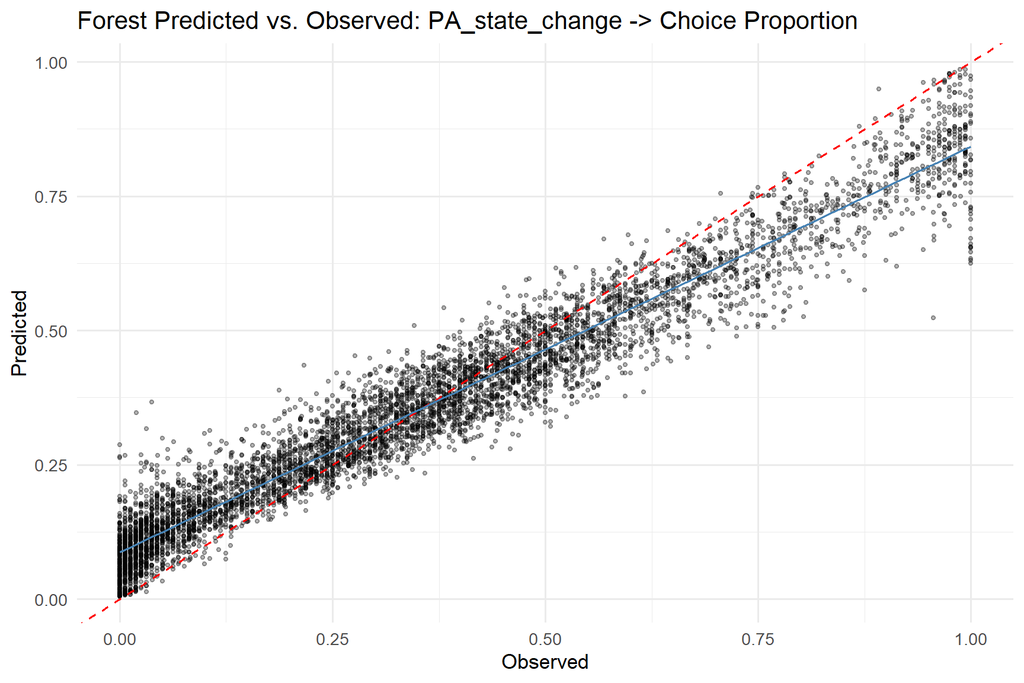

## 7.4 Model Comparison

### 7.4.1 RMSE Comparison (all methods and feature sets)

| Method | Raw | PCA | UMAP |
| --- | --- | --- | --- |
| glmm | 0.3038 | 0.3106 | 0.2831 |
| forest | 0.1927 | 0.2346 | 0.2150 |
| tree | 0.2463 | 0.2617 | 0.2648 |